# Crohnicity — solution & evaluation

*Crohnicity* = **Crohn’s** + **chronicity** — the disease and its time dimension. Crohn’s is a chronic, lifelong condition, and the health-tech AI companion records each patient’s treatment journey **longitudinally over time**, so the temporal axis is central to the data.

*Pipeline version `0.2.0` · extraction model `gemini/gemini-2.5-flash` · gold `interviews_ground_truth_v7.ods` — rendered from `config.json` / `pyproject.toml`, so this line always names the model this build used (`config.MODEL` resolves the `CROHNICITY_MODEL` env override; the model is also logged per call in `logs/extract.log`). Changes between runs: `CHANGELOG.md`.*

## Pydantic Schema Design

- Which fields should be **enums** vs. **free text** vs. **structured objects** (e.g., a list of treatment records with name, class, outcome, reason_stopped)?
- How do you distinguish **“not mentioned”** from **“explicitly denied”** from **“cut off before we could find out”**? These are three very different states and they matter for the analysis.
- How do you capture **evidence** — a supporting snippet, turn reference, or rationale per extracted field — so a reviewer can audit the model’s decisions?
- Socio-demographic fields: what’s worth extracting, what’s noise?

## Extraction Pipeline

> **Architecture diagram.** The full Dagster asset graph and the Dagster ↔︎ `uv run` relation are drawn in SYSTEM_DESIGN.md.
- **Single-shot vs. multi-stage extraction.** One big call, or a pipeline (e.g., identify-then-extract, or narrative-then-structured)? What are the tradeoffs?
- **Prompt design for uncertainty.** How do you instruct the model to separate absence, negation, and truncation?
- **Determinism and reproducibility.** Temperature, structured output mode, seed, caching — what did you pick and why?

**Answers.**

- **Single-shot, batched — not multi-stage.** One system prompt extracts *all* `PatientLabels` fields in a single structured call per patient; transcripts are then **batched** (10 per request) only to fit Gemini’s free-tier ~20-requests/day cap — batching ≠ staging, it’s still one pass over every field, just several patients per call. Single-shot minimises calls (decisive under the rate cap), keeps the code simple, and lets the model set inter-dependent fields (`biologic_prescribed`/`biologic_taken`, `churn`, `referral_pathway`) with the whole story in view. The cost: every field competes for attention in one prompt, so the hard fields suffer — the EDA shows `churn` unreliable and the GP node under-emitted. A multi-stage split (per-section prompts run concurrently, with inspectable intermediates) is the #1 item in *Next Steps* below; it trades more calls + orchestration for better per-field accuracy.
- **Uncertainty: absence vs. negation vs. truncation.** The prompt separates them by construction, onto the three schema mechanisms above. A global rule — *“Leave a field null or empty when the transcript does not support a confident value”* — covers **absence**. **Negation** rides on the prescribed-vs-taken booleans + the `ReasonNotTaken` enum. **Truncation** gets the most explicit instruction: judge `churn` from how the transcript *ends* — churn **only** when it breaks off mid-word / mid-thought (e.g. ends on “Chronic…”), while a deliberately-typed “…” on a coherent phrase is an intentional sign-off, **not** churn (no recurrence heuristic) — and — critically — *“keep this truncation signal distinct from a topic simply being absent … (that is ‘not mentioned’, not churn).”* Honest limit: truncation is a lexical/structural property of the transcript’s end that the narrative under-determines, so the instruction alone isn’t enough — the gold audit found it unreliable in both directions (over-flagging and missed truncation), and a deterministic tail-of-text rule would do better (`docs/TO_REVIEW.md`).
- **Determinism & reproducibility.** Three levers, in decreasing order of leverage. **(1) Structured-output mode** — `response_format={"type": "json_object", "response_schema": PatientLabels.model_json_schema(), "enforce_validation": true}`: a Pydantic-derived schema constrains the *shape* and enum membership, and LiteLLM validates the reply (raising `JSONSchemaValidationError` on a mismatch), so format/parse variance is removed and downstream pandas never meets an off-vocabulary value. **(2) Persisted predictions** — each chunk writes one validated JSON per patient to `data/out/`, and the whole analysis (this document) reads *only* those frozen artefacts with no API call, so every number and plot is **exactly reproducible run-to-run** regardless of LLM nondeterminism; this is the real guarantee. **(3) Decoding params** — `temperature` is **pinned to `0`** (greedy) in `config.json` and imported by `extract.py` — extraction here is a **classification** task, so we want *same transcript → same labels*, not sampled variety. This build is the live test case for *why*: a fresh re-run at the provider default (Gemini’s default `temperature` is `1.0`) shifted long-tail outputs (the GP-node count; which biologics got mislabelled on `biologic_timing`) while the headline answers held — exactly the run-to-run drift `0` removes. Temperature is **logged per run** (with the model) so runs at different parameter levels stay comparable. A seed would add belt-and-braces, but with a reasoning-capable model `0` *minimises* rather than *guarantees* bit-identical output; **(2)** is the hard reproducibility guarantee for the analysis. **Reasoning is also disabled** — `reasoning_effort="disable"` (LiteLLM → Gemini `thinkingConfig.thinkingBudget=0`, verified via `get_optional_params`) — because extraction is *classification*, not multi-step inference: the hidden thinking step added run-to-run variance and on `gemini-2.5-flash` consumed the output budget until the JSON truncated mid-array (a `JSONSchemaValidationError`), with no accuracy upside. The *inspectable chain-of-thought* the stretch brief asks for is a **different** thing — explicit multi-stage prompts with auditable intermediates (the #1 *Next Step* above), not opaque internal tokens. No explicit prompt **caching** yet — the static system prompt + schema are identical across calls, so implicit context caching may apply, and cached-token counts are logged (`docs/TELEMETRY.md`).

## Evaluation

Pick **one** approach that gives you a real signal on quality. We don’t need a rigorous eval harness — we want to see you know how to probe your own pipeline:

1. **Mini golden set:** hand-label 5–10 transcripts yourself on key fields, compute agreement with the model, **or**
2. **LLM-as-judge:** a second LLM call scoring extraction fidelity on a sample against the source transcript, **or**
3. **Consistency check:** run extraction twice (different prompts, temperatures, or models) and use disagreement as a proxy for reliability.

Write up what it told you in a few lines: what the pipeline is solid on, where it’s shaky, what you’d fix first with more time.

I picked (1).

**What it surfaced.** Gold labels live in interviews_ground_truth_v7.ods, scored on the human-reviewed gold set (`to_review == 1`). Headline: `biologic_taken` — the field Q1 rests on — scores a high F1 (precision / recall / F1 computed inline in the Q1 gold-eval table below), so the “% on a biologic” answer is well-supported. Where it’s shaky: **`churn`** is unreliable in both directions (a false positive *and* a false negative in the gold audit — `docs/TO_REVIEW.md`) because truncation is a lexical/structural signal the narrative under-determines; **`treatment_class`** drifts (un-normalised free-text categories inflate the Q3 count); and the **GP node** (`primary_care_contact`) is under-emitted (see the Q4 caveat’s live count), weakening the strict Q4 step count. Fix-first order: a deterministic tail-of-text churn rule, a treatment/biologic registry to normalise classes, and a larger, multi-annotator gold set — today’s is single-annotator over the `to_review` gold set, so the metric carries real sampling uncertainty.

**Edge case — biologic over-detection (P047).** P047’s transcript names *no* biologic (conventional therapy only — prednisone, mesalamine, methotrexate), yet the model returned `biologic_prescribed=True` with a fabricated `DOCTOR_CHOICE` reason — a hallucination inferred from disease severity, because the biologic-funnel booleans had no prompt guidance. Two fixes landed: P047 is now a reviewed gold case (`biologic_not_mentioned=1`, `biologic_prescribed=0`), and `system.txt` now instructs the model never to *infer* `biologic_prescribed` and to set `biologic_not_mentioned` when no biologic is named. Tellingly, this error sat in the then-unreviewed cases — invisible to the gold metric until P047 was reviewed.

> **A second eval, by accident — the temperature consistency check (option 3).** I picked (1), but the rate-limited re-runs left a natural option-(3) experiment, and it **supports the `temperature = 0` decision** (*Extraction Pipeline → Determinism*). The *same* `P001–P010` batch (identical transcripts + prompt) was extracted three times at Gemini’s default `temperature = 1.0` and twice at the now-pinned `0`, and the result is textbook: at **`1.0` the output drifts** — `total_tokens` of **11,570 / 12,260 / 12,197** across runs (~6% spread; input is fixed, so a moving total means *different generated content* each run) — whereas at **`0` it is byte-identical** (**12,034 = 12,034**), i.e. same input → same output. So determinism here is *demonstrated, not asserted*. Caveats: `total_tokens` is a coarse, **lower-bound** proxy (it only catches drift that changes output *length*, so field-level drift at `1.0` is likely larger), and the temp-0 sample is n=2 from one session. **With more time** I’d run the check deliberately — all 50 patients ×2 at each temperature, diffing the JSON field-by-field — turning this accidental signal into a measured disagreement rate.

## Analysis

A short answer to PharmaCorp’s four questions. Numbers with ranges or caveats where sensible. Keep it tight — the point is to demonstrate the structured output is usable, not to write a consulting deck.

1. What percentage of patients in the dataset appear to be on a biologic?
2. For patients *not* on a biologic, what are the primary reasons (doctor choice, patient fears, cost, access, something else)?
3. What other treatments are commonly tried or discussed before a biologic is considered?
4. What does a typical referral pathway look like, in number of steps from GP to a specialist who can prescribe a biologic?

### Answers

Computed from the persisted predictions in `data/out/` (`n = 50`).

#### Q1 — % on a biologic

| status | patients | pct |
| --- | --- | --- |
| on a biologic (taken) | 37 | 74 |
| not on a biologic | 13 | 26 |

74% of patients (37/50) appear to be **on a biologic** (`biologic_taken == true`).

*Evaluation — mini golden set.* `biologic_taken` (the field Q1 rests on) scored against the hand-annotated gold in interviews_ground_truth_v7.ods (the `to_review` cases), as precision / recall / F1:

| metric | value |
| --- | --- |
| precision | 0.9 |
| recall | 1 |
| F1 | 0.947 |
| accuracy | 0.95 |
| n (gold) | 20 |

On the 20-case golden set, `biologic_taken` scores **F1 = 0.95** (precision 0.9, recall 1.0; TP/FP/FN/TN = 9/1/0/10) — so the Q1 headline is well-supported by the gold.

*Limitation.* This is measured only on the hand-annotated gold (`to_review`) set — **20 of 50** patients (those with a non-null `biologic_taken`) — so the metric carries real **sampling uncertainty** (a few flips would move it noticeably), and the gold is a **single-annotator judgement** with its own error. A trustworthy at-scale accuracy estimate would need a larger, ideally multi-annotator audit set (a bigger `…_v*.ods`); see `docs/TODO.md`.

#### Q2 — reasons not on a biologic

| reason | mentions |
| --- | --- |
| INSURANCE_PROBLEMS | 5 |
| PATIENT_FEARS | 4 |
| COST | 3 |
| DEFERRED | 2 |
| NOT_APPLICABLE | 1 |
| CONTRAINDICATION | 1 |

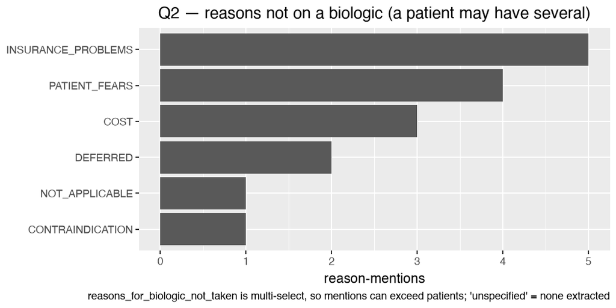

Q2 reasons not on a biologic

> **`unspecified` (Q2) — null handling.** An `unspecified` row is a biologic **prescribed but not taken** with an **empty `reasons_for_biologic_not_taken`** list (`[]`) — no reason extracted, not a stated one. It’s kept **visible as its own category** rather than dropped — consistent with the schema’s stance on nulls (*Pydantic Schema Design → “Three states, not one null”*): absence, negation and truncation are distinct first-class states, and `UNKNOWN` / `NOT_APPLICABLE` exist so a missing value is never silently conflated with a real one. `system.txt` now requires a **never-empty** list (`[UNKNOWN]` for prescribed-but-not-taken with no stated reason, `[BIOLOGIC_TAKEN]` when a biologic was taken), so `unspecified` should disappear on the next extraction run.

#### Q3 — treatments tried before a biologic

```
| treatment_class   |   mentions |
|:------------------|-----------:|
| 5-asa             |         48 |
| corticosteroid    |         40 |
| immunomodulator   |         37 |
| nsaid             |          2 |
| other             |          1 |
| antibiotic        |          1 |
```

[figure not shown]

Q3 treatments before a biologic

#### Q4 — referral pathway length (steps to a biologic-prescribing specialist)

> **Caveat.** The literal “GP” node (`primary_care_contact`) appears in only 7/50 predicted pathways, so a strict GP→prescriber count isn’t representative. We count steps from the journey **start** (or `primary_care_contact` where present) to `biologic_recommended` (present in 27/50) — the point a biologic-prescribing specialist is reached. Under-emission of the GP node is a prompt-fix candidate (see `docs/TODO.md`). The per-case interactive journey graphs are linked below.

| steps | patients |
| --- | --- |
| 9 | 5 |
| 10 | 4 |
| 6 | 4 |
| 13 | 3 |
| 8 | 3 |
| 7 | 2 |
| 5 | 2 |
| 12 | 1 |
| 11 | 1 |
| 15 | 1 |
| 14 | 1 |

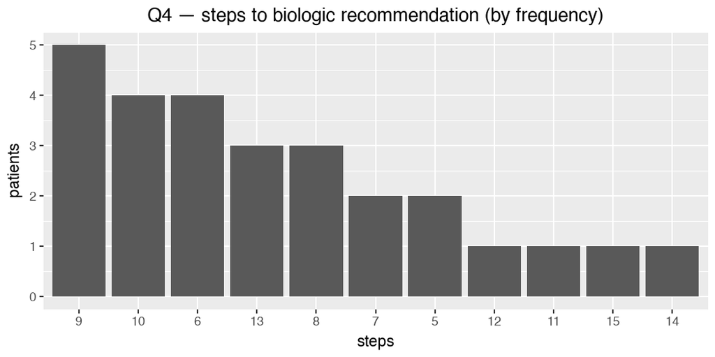

Q4 steps to biologic recommendation

The **most common** journey length is **9 steps** (the modal value — highest patient count in the chart), with a **median of ~9** (range 5–15, n=27).

Crucially, **47/50 journeys are cyclic** — the patient loops back through relapse / `loss_of_response` / `biologic_switch` (recurrence the prompt now captures; the per-case graphs render these as loops — see the deep-dive below). So “a typical referral pathway” is as much about **recurrence** (repeated biologic switching) as about step count — a linear step number alone understates the journey for the **94%** of patients whose journey loops.

**Deep dive — the individual journeys.** Two views of the same data: a GitHub-viewable static gallery of all 50 pathways as Mermaid diagrams in referral_pathways.md, and the **interactive** pyvis graphs in `data/out/html/` (open `index.html`) — these render **live in a browser from a local clone**; GitHub only shows them as source. As a teaser, here is patient **P046** — a *cyclic* journey (a phase recurs, so it renders as a loop):

```
%%{init: {'theme':'neutral'}}%%
flowchart LR
    n0["symptom_onset"]
    n1["crohns_diagnosis"]
    n2["conventional_therapy"]
    n3["adverse_reaction"]
    n4["therapy_failed"]
    n5["biologic_taken"]
    n6["unresolved"]
    n0 -->n1
    n1 -->n2
    n2 -->n3
    n3 -->n2
    n2 -->n4
    n4 -->n5
    n5 -->n6
```

**Churn handling matters here.** Be explicit about:

- How many journeys in your output look truncated vs. complete, and how you decided.
- How you separated “biologic not mentioned” from “biologic discussed and rejected” from “patient churned before reaching that point.”
- Which of the four answers are most and least trustworthy given the churn distribution, and why.

| state | patients |
| --- | --- |
| biologic not mentioned (absence) | 0 |
| discussed but not taken (negation) | 12 |
| churned / truncated | 2 |

The model flagged `churn = true` for only **2/50** patient(s). Manual review of the flagged/edge cases (`docs/TO_REVIEW.md`) found churn detection unreliable in both directions — both an over-flag and a missed truncation — because truncation is a lexical/structural property of the transcript’s *end* that the narrative under-determines. **Q1 and Q3 are the most trustworthy** answers (they depend on facts stated early); **Q4 is the least** (it depends on the full pathway surviving, and on the under-emitted GP node).

### Churn — definition & handling

**Definition.** The spec never defines the “interview”. We read it as the patient’s interaction with the health-tech AI companion app — patients describe their doctors in the *third person*, so they’re narrating *to the app*, not conversing with a clinician. **Churn is therefore disengagement from that app interaction**, which in the data shows up as a transcript that stops early. The spec backs this: *“patients disengage partway through their interview — they churn — leaving us with truncated journeys”*, and the transcripts vary in *“completeness… some cut off mid-journey”* (with a worked “incomplete, likely churn” example).

**One flag, not two.** Because “churned” and “incomplete journey” are the *same* signal under this reading, we collapse them into a single `churn` field (the ground truth drops `incomplete_journey`). `churn = true` when there’s evidence of **(a)** disengagement from the app interaction, or **(b)** a truncated / cut-off / vague narrative. Signals: completeness, cut off mid-journey, truncation, vagueness.

**Deciding churn from a trailing `"..."`.** A trailing `"..."` is ambiguous — it can be an intentional emotional sign-off *or* a real cut-off — and we have no behavioural signal (e.g. a last-login timestamp) to disambiguate, so we decide from the text alone: **churn only when the transcript breaks off mid-word / mid-thought**, not when it closes on a coherent phrase. We do **not** use whether `"..."` recurs elsewhere (an earlier heuristic we dropped).

- **Mid-thought break → churn:** P049 `"…Different but same. Chronic..."` — ends on an incomplete fragment (“Chronic” with no following noun), so the interview was genuinely cut off.
- **Coherent emotional close → NOT churn:** P016 `"…better than this..."`, P036 `"…Don't want to know..."`, P045 `"…but it's hard..."`, P046 `"…how people manage..."`, P047 `"…Not worry about mom..."`, P048 `"…I'm only 56..."` — the patient *typed* the ellipsis, a deliberate sign-off, not a disconnection.

**Why this matters for the answers.** `churn` is the *truncation* state that, with `biologic_not_mentioned` (absence) and a discussed-but-not-taken biologic (negation), gives the three-way split the analysis needs — “not mentioned” vs “discussed and rejected” vs “churned before we could find out”. It stays a judgement call with residual uncertainty, but a single honest flag beats splitting two overlapping ones.

## Optional stretch tasks

The brief offers five optional stretches but asks for *a tight core over a bloated stretch*, so I picked the one that directly answers a business question and put the rest of my effort into reproducibility and orchestration.

**Attempted.**

- **(4) Pathway visualisation — successful.** The interactive per-case referral-journey graphs (the deep-dive under Q4) answer business question 4. I chose a directed graph over a Sankey deliberately — it shows *recurrence* (relapse / loss-of-response loops), which a Sankey flattens.
- **(3) Open-source model swap (local Ollama) — attempted, an instructive failure.** The plumbing works: `--model` routes extraction through any LiteLLM-supported model with no code change (e.g. `uv run python src/main.py --model=ollama_chat/qwen3:30b-a3b` for a local Qwen, also a way to dodge the Gemini quota), and `extract()` drops provider-unsupported params automatically. But the local models I tried did **not** return reliable schema-valid output — they invent fields and off-vocabulary enum values, so `tests/test_ollama.py` records this as a graceful `xfail` rather than a pass. **Insight:** the strict structured-output + `enforce_validation` Gemini honours is exactly where local models fall down, so the swap isn’t drop-in for this task — it would need a tolerant per-record parse (or a JSON-tuned model) first.

**Beyond the brief’s list — extra stretches I added.**

- **Dagster orchestration.** The whole pipeline is an asset graph (`uv run dg dev`), so a failure is pinpointed per-stage in the UI instead of as one opaque error — and the same `src/` functions still run standalone from the CLI (SYSTEM_DESIGN.md).
- **Determinism + an accidental consistency check.** `temperature = 0` is pinned, and the repeated runs gave a free reliability signal — a partial take on stretches (2)/(3) (see *Evaluation* and *Extraction Pipeline → Determinism*).
- **Reproducible reporting + an API docsite.** This write-up is Quarto-rendered from the persisted predictions (no API call), and a MkDocs + mkdocstrings site documents the `src/` API.
- **Centralised config + a quality gate.** One `config.json` feeds every entry point; `ruff` / `ruff format` / `ty` / `pytest` (with coverage) gate every change.

**Deferred to keep the core tight** (tracked in *Next Steps* / `TODO.md`).

- **(1) Multi-stage / chain-of-thought prompts** with inspectable intermediates — my #1 *Next Step*.
- **(2) Per-field confidence scoring** (self-reported, or from consistency across samples).
- **(5) Dockerfile** for cross-machine reproducibility.

## Next Steps

With more time, after the core is complete:

- **Split the single system prompt into multiple focused prompts run concurrently.** This version deliberately uses one prompt; a later iteration would split it **by task** into focused prompts run in parallel — **(1)** biologic funnel (prescribed/taken/type/reasons), **(2)** treatment history (records + `biologic_timing` + outcome), **(3)** referral pathway, **(4)** context (churn, demographics, comorbidities) — then merge into one `PatientLabels`. Better per-field accuracy and inspectable intermediates, at the cost of more calls and orchestration. **This is where chain-of-thought genuinely earns its place here:** as the *explicit, inspectable* reasoning the stretch brief means, it both fixes the single-shot attention-competition behind shaky `churn`/`referral_pathway`/`biologic_timing` **and** hands a reviewer auditable intermediates (the brief’s whole point). So we turn off the *opaque* internal thinking now (*Determinism & reproducibility* above) and add *explicit* staged CoT here — complementary, not contradictory.
- **A telemetry feature for optimisation.** Per-call usage is currently logged (tokens, cost, cached tokens — see TELEMETRY.md); with more time I’d surface it as a first-class artifact (a structured per-run metrics file + plots) to track cost/latency/cache-hit rate and tune the pipeline at scale.
- **Try an even larger Gemini model.** This run uses gemini/gemini-2.5-flash (it ran on `gemini-2.5-flash-lite` during iteration, then moved up to dodge `-lite`’s 503 spikes and give the batched JSON enough output budget). With more time I’d evaluate `gemini-2.5-pro` for extraction quality, weighed against its free-tier **request/token rate limits** (the ~20 calls/day cap that drove the chunking design) and cost.
- **Deep dive on cyclical journey patterns.** The `referral_pathway` initially flattened recurrence (each phase emitted once); the prompt now asks the model to repeat steps when phases recur. A proper follow-up would analyse the *cyclicity* itself — how many biologics patients cycle through, repeated relapse / loss-of-response / switch loops, time-to-switch — and classify journeys as genuinely cyclic vs linear (the recurrence is also recoverable from `treatment_records`).
- **Productionise as a FastAPI inference endpoint (deployment MVP).** Wrap `extract()` in a **FastAPI** service (already a declared dependency): `POST` an `interview_transcript`, get back a validated `PatientLabels` JSON generated **dynamically by a cloud-hosted model** — turning the current offline batch CLI into a real-time production inference path. Package the API **into the Docker image** (the Packaging item in `docs/TODO.md`) so one container serves it, and ship it via **CI/CD to a cloud service** for an always-on, auto-deployed endpoint.
- **SQL + dbt for transformation layers at scale (once they’re better defined).** The post-extraction aggregations (Q1–Q4, the churn three-way split) are pandas in `src/post_extraction_eda.py` — fine for 50 patients and a single analyst, and the right tool while the transformations are still *exploratory* and in flux. **Once the analytics transformation layers are better understood** — at cohort scale, across a team — I’d lift the stabilised ones into **dbt** models: version-controlled, tested, documented SQL over a warehouse, with lineage — modular and collaboratively maintained rather than ad-hoc DataFrame wrangling. It slots into the existing **Dagster** orchestration via `dagster-dbt` (dbt models become assets in the same DAG).
- **Pipeline optimisation: Arrow-backed pandas, then Polars / DuckDB + Parquet.** The EDA currently loads 50 per-patient JSON files into default (NumPy-backed) pandas in memory. A low-effort first win for query times: switch pandas to the **PyArrow dtype backend** (`dtype_backend="pyarrow"`) — faster, lower-memory columnar ops with near-zero code change. Beyond that, benchmark **Polars** (lazy, multi-threaded) and **DuckDB** (in-process analytical SQL straight over the artefacts), persisting predictions as **Parquet** (columnar, compressed) instead of loose JSON — faster aggregations and a format that scales. DuckDB also doubles as the local warehouse for the dbt step above.
- **Lift test coverage on the orchestration + LLM-call paths.** The gate reports coverage (`pytest --cov`): **64%** total — but that headline hides a deliberate shape. The **pure logic is well-covered**: `schema` and `config` at 100%, and `post_extraction_eda` (every analysis number in this write-up) at 98%. The gaps fall **exactly on the side-effecting I/O boundary** — the code you can’t exercise without mocking an external service: the live `litellm` call in `extract.py` (36%) and the `main.py` / `pipeline.py` entry points (0% — the fire CLI + the Dagster assets, which shell out to Gemini, `quarto` and `mkdocs`). So the untested code is the **plumbing, not the analysis**. With more time I’d **mock the `litellm` call** to exercise the retry / schema-rejection / partial-output branches without hitting the API, test the CLI slicing, and smoke-test the Dagster `Definitions` load — closing the gap where reliability, not correctness of the numbers, is at stake.
- **Explore patient journey narratives as complaints.** The `interview_transcript` patient narratives read like complaints. There is a research literature in Conversation Analysis (CA) on complaints and narrative storytelling. I would see if this social scientific research has insights for identifying patterns in complaints that could upgrade the prompts to enhance classification of the parts of the narratives.

## Where I used AI

### Without AI

- At beginning of project, I did not use AI. I read the task instructions ~5 times, started handwriting a plan of action, and did system design and designed the Pydantic schema at a high level - making notes of questions - as I read/re-read the task. I was also thinking about how I would incorporate AI into my dev workflow later.
- I wrote ~6 pages of handwritten notes as I designed “Crohnicity”.
- After deciding to read, review and annotate the `interviews.json` `interview_transcript` dataset, I did annotations by hand in LibreOffice Writer (open source version of Excel) to mimic non-technical domain expert labeling of a “gold” ground truth dataset. I returned to this dataset and manual labeling throughout the process, labeling ~21/50 cases.
- I wrote the code for the beginning notebooks (`00_setup`, half of `01_eda_transform_export`) by hand, before transitioning to Claude Code for the more tricky programmatic updates to my LibreOffice Write `.ods` spreadsheet files (see next section).
- I would always do `git` commands (`add`, `commit`, `pull`, `push`) myself manually via `!` commands in the CC terminal.
- I would run the CLI script commands to execute the tests/pipelines in a separate terminal to make sure CC was not hallucinated execution/output.
- At the end of the process, I ran Dagster commands from the CLI and used the Dagster UI to check if my pipelines were running with success/failure.
- I wrote this “Where I used AI” section without AI, by hand!

### With AI

- After clarifying the project specification and system design and how I was going to work with AI, I started using Claude Code in a terminal in my VS Code. Initially I was going to use SKILLS/*.md files, but decided this was overkill. So I used “Explanatory mode” which is for software engineers and offers explanations while you code. I exported the CC chat with `/export` as I went, to review the workflow. CC opened windows so I could compare diffs in my VS Code using the Claude Code extension. This was really effective. I was conservative and only allowed CC to make changes after my manual approval.
- I did pretty much all the dev work with Claude Code, starting off with writing all the unit tests, logging outputs, and Pydantic schema validation versions using what I would call a “agentic engineering” perspective. I questioned every decision, was pretty strict, and used my judgement either to approve or override CC. I checked all code and outputs as much as I could in VS Code via diffs or using VS Code as a code viewer/editor.
- For the agentic engineering, I was very test- and data- and log- and doc-driven so that I could inspect the outputs at every stage and compare against expected versions. This worked pretty well and either I or CC caught issues as they emerged in the dev process.
- Most of the docs in `docs/` were generated with CC, so there is a potential for drift with the implementation. However, the Quarto `SOLUTION.qmd` is programmatic to ensure all the data values are dynamically generated rather than hardcoded.
- I was very much “data science” style in my dev workflow, iterating using the data output, and validating against the tests, as much in a REPL style as possible.

## Usage

**Dagster, driven by the `dg` CLI, is the main entry point.** It orchestrates the whole pipeline end-to-end — extract → (EDA/SOLUTION render · referral graphs · referral-pathway gallery) → docsite — and shows which stage failed in the UI. Launch a run two ways — the UI’s *Materialize all*, or headless from a second terminal:

```bash
uv run dg dev -m pipeline -d src -p 3050   # UI at http://127.0.0.1:3050 → "Materialize all" (port: config.json → dagster_port)

# ...or headless from another terminal (no UI):
uv run dg launch --assets "*" -m pipeline -d src
```

> `DAGSTER_HOME` is set in `.env` to `.dagster_home/` (see DEV_SETUP), so Dagster persists run history there — **not** a temp dir (a temp dir is only the fallback if the var is unset). The instance config `.dagster_home/dagster.yaml` is committed (it shows the pipeline wiring); the sqlite run-state is git-ignored. Dagster runs **locally only** — it never pushes to GitHub, so publishing refreshed artefacts (data + logs + SOLUTION) is your separate `git` step.

The processes below are the stages Dagster orchestrates; each also runs **standalone** to drive or test one part on its own (Dagster calls the same `src/` functions — it doesn’t shell around them). Extraction uses the chunked 10×5 batch strategy to fit the Gemini free-tier ~20-requests/day cap.

### Extraction (`src/main.py`)

Run the extraction pipeline via the `src/main.py` CLI (python-fire). **By default it extracts all 50 transcripts in chunks of 10 → 5 API calls**, sized to the Gemini free tier’s ~20 requests/day cap (taken as a fixed constraint; 50 one-at-a-time calls would exceed it).

**Retries are quota-sparing.** On the free tier a *failed* request costs the same daily quota as a successful one, so retry policy is deliberately frugal and **treats the two error classes differently**: litellm’s own auto-retries are **off** (`num_retries=0`), so one failure is one request — not three. (Why off, not just lower? `num_retries` is one knob across *all* error types, but a daily quota needs *opposite* policies — retry 503, never 429 — which a single count can’t express; litellm’s per-exception `RetryPolicy` is Router-only, not on `litellm.completion()`, so we switch the blanket retry off and own a tiny loop, `_with_503_retry`.) A **429** (rate-limit / daily quota) **fails fast** — no retry, since retrying a spent quota only burns more of it — while a **503** (transient model overload) is retried **sparingly** (up to 4 retries, 60s apart — set in `config.json`), then gives up. The **stop-vs-retry decision is in the code** (`give_up_reason`), not left to manual log-watching: the failure message states the action — **429 → stop** (the quota won’t clear by retrying; wait for the reset), **503 → wait and re-run**. Full table: `DEBUGGING_ERROR_HANDLING.md`.

```bash
uv run python src/main.py                          # all 50, chunks of 10 (5 calls)
uv run python src/main.py --limit=10               # run 1 only: P001–P010
uv run python src/main.py --limit=10 --offset=10   # run 2: P011–P020 (no re-run of earlier chunks)
```

| Flag | Default | Purpose |
| --- | --- | --- |
| `--model` | gemini/gemini-2.5-flash | swap model (Gemini ↔︎ local Ollama, e.g. `ollama_chat/qwen3:30b-a3b`) |
| `--limit` | all | slice size — run one chunk for testing / incremental runs |
| `--offset` | `0` | which slice — incremental runs without redoing earlier chunks |
| `--chunk-size` | `10` | transcripts per API call |
| `--out-dir` | `data/out` | route test runs to `data/out/tests` so they don’t clobber production |

The post-extraction EDA (this write-up’s tables/plots) is generated by `uv run quarto render docs/SOLUTION.qmd`, which reads only `data/out/` — **independent of the Gemini API**. Each chunk persists its predictions (one JSON per patient) as soon as it validates, so a completed chunk is durable and `--offset` lets you resume/retry without re-spending calls. Per-call telemetry (tokens, cost) is logged to `logs/extract.log`.

### Referral-pathway graphs

Generate the per-case journey graphs + phase/transition tables behind Q4 (reads the pathways, no API call):

```bash
uv run python src/referral_pathway_analysis.py   # writes data/out/html/referral_pathway_P*.html
```

### Rebuild the answers doc

```bash
uv run quarto render docs/SOLUTION.qmd                  # regenerate SOLUTION.md (gfm) + SOLUTION.html from data/out/
```

### Development — quality gate

Run the manual gate on every code change (no pre-commit hooks, by design — see `CLAUDE.md`):

```bash
bash tests/type_lint_unit_tests.sh   # ruff check + ruff format --check + ty check + pytest (src + tests)
```

…or the individual tools:

```bash
uv run ruff check src tests                            # lint
uv run ruff format src tests                           # auto-format
uv run ty check src tests                              # type-check (Rust-based; not mypy)
uv run pytest -q                                       # unit tests
RUN_RENDER_TEST=1 uv run pytest tests/test_render.py   # gated end-to-end render smoke test
```

### Docsite (API reference)

Preview the mkdocstrings API site locally — it regenerates from the docstrings on every build:

```bash
uv run mkdocs serve -a localhost:8000   # live preview at http://localhost:8000 (port: config.json → docsite_port)
uv run mkdocs build   # render the static site to site/ (gitignored)
```

## Data handling & privacy

> ⚠️ **This repo commits `data/in/` and `data/out/` (model inputs and outputs) to git — which you should NOT do in a production system.** Real patient interview data and extracted records are **personal / special-category health data** under GDPR and must never be pushed to GitHub or any external version control — PII exposure, data-residency, retention, and access-control all forbid it.

> It is acceptable **here only** because the dataset is **synthetic**, the repo is **private**, and committing the data + outputs makes this **internal job-interview take-home auditable** end-to-end by the reviewer. In production, inputs/outputs would live in secure storage under a data-processing agreement and **only code** would be version-controlled. See QUESTIONS.md #7.

## Requirements

Dev environment requirements and setup — Python 3.14 (via uv), a `GEMINI_API_KEY`, and the VS Code + Claude Code extension diff-review workflow — are documented once in DEV_SETUP.md; this write-up only links there to avoid duplication.

## Docs & further reading

Project instructions are in CLAUDE.md; the rest lives in `docs/`:

*Design & decisions*

- SYSTEM_DESIGN.md — architecture diagram: the Dagster asset graph + the library-first CLI/gate relation.
- SCHEMA.md — the ground-truth annotation schema and the Pydantic-model rationale.
- QUESTIONS.md — outstanding questions for the CAIO (assumptions needing a domain decision).
- HYPOTHESES.md — early hypotheses about the data and the disease journey.

*Process & operations*

- DEV_SETUP.md — local dev setup: uv, the Jupyter kernel, Dagster (`dg`), the quality gate.
- TODO.md — deferred engineering tasks + the *Tomorrow — pre-interview* checklist (the clean `temperature=0` re-run).
- TELEMETRY.md — per-call API telemetry (tokens, cached tokens, cost, latency) and how to read it.
- TO_REVIEW.md — the manual gold-set edge-case audit (the churn false-positive / false-negative findings).
- DEBUGGING_ERROR_HANDLING.md — debugging notes + error-handling behaviour seen in development.

*Reference*

- RESOURCES.md — external references (Crohn’s pathways, biologics).
- TASK_INSTRUCTIONS.md — the original health-tech take-home brief.

### Browse the docs locally (MkDocs)

`docs/` plus an auto-generated `src/` API reference render as a small site via [MkDocs](https://www.mkdocs.org/) + mkdocstrings:

```bash
uv run mkdocs serve -a localhost:8000     # live preview at http://localhost:8000 (hot-reloads; port: config.json → docsite_port)
uv run mkdocs build     # render the static site to site/ (git-ignored)
```

`mkdocs build` is wired as the `docsite` asset, which depends on `referral_pathways_md` so the journey gallery is re-rendered from the latest predictions before the site is built (see SYSTEM_DESIGN.md).

## Project layout

```
.
├── src/                              # pipeline library (imported by BOTH Dagster + the CLI)
│   ├── config.py                     #   central config loader (reads config.json)
│   ├── schema.py                     #   Pydantic models + enums (PatientLabels, …)
│   ├── extract.py                    #   the Gemini call — chunked, structured-output, temperature=0
│   ├── main.py                       #   fire CLI: load → run_chunked → persist
│   ├── pipeline.py                   #   Dagster assets: interviews → predictions → readme/graphs/pathways-md → docsite
│   ├── post_extraction_eda.py        #   pure analysis fns over data/out (power the write-up + tests)
│   └── referral_pathway_analysis.py  #   per-case journey graphs + the gallery index.html
├── tests/                            # pytest suite + the quality gate
│   ├── test_*.py
│   └── type_lint_unit_tests.sh       #   ruff + ruff format + ty + pytest (the gate)
├── data/                             # in/ static input (interviews.json + gold .ods) · out/ generated artefacts (json · html · plots) · prompts/
├── docs/                             # design notes + the MkDocs docsite source (above)
├── notebooks/                        # jupytext-paired prototyping (.py is the edit source)
├── sandbox/                          # one-off scripts kept as a dev record (gold-set builders)
├── logs/                             # loguru run logs (extract · referral · dagster) + litellm debug
├── config.json                       # single source of truth for params (model, temperature, paths…)
├── pyproject.toml / uv.lock          # uv-managed deps + lockfile
├── mkdocs.yml                        # docsite config
└── docs/SOLUTION.qmd → docs/SOLUTION.md   # this write-up (edit the .qmd, render to .md)
```